# Summarization of Large Pieces of Text with LangChain

## Context

Modern NLP systems excel at text summarization--extraction of features which retain the meaning of the piece of text, as well as reformulating them into *new* sentences. However, as the task grows in complexity because of inherent limitations of the LLMs to consume, and timely process the text, it is necessary to create a specific strategy to perform summarization of larger pieces of text such as whole books.

## Objective

As partially revealed in previous paragraph the objective of this demo is to create a summary of the text that is several times greater than the current limitation in terms of tokens that can be consumed by LLMs. While, the only limitation appears to be number of tokens, other limitations need to be taken into account as well: cost, speed, overall quality in order to meet the objective.

## Technological Stack

The back-end of the whole system is the LangChain library. However, its scope will be limited to utilization of only some classes, such as: `RecursiveCharacterSplitter`, `PromptTemplate`, and `Document`. While, `LangChain` does provides classes to perform summarization of large pieces of text into chains, there is always a benefit in balancing between the utilization of pre-existing classes and custom implementation. In this case custom implementation will handle the splitting of the text and further summarization chain. The choice of the LLM has fallen to `OpenAI`s GPT-3.5-Turbo which can consume 4096. tokens. The compete system is monitored via `LangSmith` platform.

## Architecture

Having in mind that complexity of the task lies in the whole system design, the architecture of the LLM sub-system is fairly simple. It is a LLM based on a custom prompt containing instructions on how to summarize two pieces of text.

## Implementation

Firstly, let us make the necessary imports.

```python
%matplotlib inline
from collections import OrderedDict
from utilities.text import TextLoaderManager
from summarizer.summarizer import TextSplitterManager, SummarizationManager, \
    TextPlotterManager
```

Secondly, let us delare a file handle for the folder with the data.

```python
TEXT_FOLDER = r'C:\Users\marko\Desktop\data'
```

Now let us utilize the `TextLoaderManager` class to load the text files.

```python
text_loader = TextLoaderManager(folder=TEXT_FOLDER)
text_loader.read_files()
texts = text_loader.get_pieces_of_text()
```

Here is a dictionary with the names of the books that and the files.

```python
book_names = OrderedDict(
    [
        ('pg11.txt', "Alice's Adventures in Wonderland"),
        ('pg1513.txt',  'Romeo and Juliet'),
        ('pg2554.txt', 'Crime and Punishment'),
        ('pg2680.txt', 'Meditations'),
        ('pg345.txt', 'Dracula'),
        ('pg66073.txt', 'Death in Venice'),
        ('pg69087.txt', 'The murder of Roger Ackroyd'),
        ('pg76.txt', 'Adventures of Huckleberry Finn')
    ]
)
```

The next step is to split the documents, according to the methodological specification.

```python
text_splitter = TextSplitterManager(pieces_of_text=texts)
text_splitter.split_documents()
split_documents = text_splitter.get_split_documents()
```

```
Text with: 163918 characters, split into 128 pieces with chunk size: 1312.
Text with: 161777 characters, split into 128 pieces with chunk size: 1288.
Text with: 1154409 characters, split into 128 pieces with chunk size: 9056.
Text with: 417454 characters, split into 128 pieces with chunk size: 3304.
Text with: 865173 characters, split into 128 pieces with chunk size: 6792.
Text with: 184065 characters, split into 128 pieces with chunk size: 1472.
Text with: 421532 characters, split into 128 pieces with chunk size: 3328.
Text with: 590379 characters, split into 128 pieces with chunk size: 4648.
```

Finally it is possible to start the `SummarizationManager` and to create summaries of documents.

```python
summarizer = SummarizationManager(chuncked_pieces_of_text=split_documents)
summarizer.summarize_text()
summarized_text = summarizer.get_summarized_texts()
```

```
--- Summary cycle: 1, pair: 0
--- Summary cycle: 1, pair: 4
--- Summary cycle: 1, pair: 8
--- Summary cycle: 1, pair: 12
--- Summary cycle: 1, pair: 16
--- Summary cycle: 1, pair: 20
--- Summary cycle: 1, pair: 24
```

[output not shown]

```
--- Summary cycle: 1, pair: 28
--- Summary cycle: 1, pair: 32
--- Summary cycle: 1, pair: 36
--- Summary cycle: 1, pair: 40
--- Summary cycle: 1, pair: 44
--- Summary cycle: 1, pair: 48
```

[output not shown]

```
--- Summary cycle: 1, pair: 52
--- Summary cycle: 1, pair: 56
--- Summary cycle: 1, pair: 60
--- Summary cycle: 2, pair: 0
--- Summary cycle: 2, pair: 4
--- Summary cycle: 2, pair: 8
```

[output not shown]

```
--- Summary cycle: 2, pair: 12
--- Summary cycle: 2, pair: 16
--- Summary cycle: 2, pair: 20
--- Summary cycle: 2, pair: 24
--- Summary cycle: 2, pair: 28
```

[output not shown]

```
--- Summary cycle: 3, pair: 0
--- Summary cycle: 3, pair: 4
--- Summary cycle: 3, pair: 8
--- Summary cycle: 3, pair: 12
--- Summary cycle: 4, pair: 0
```

[output not shown]

```
--- Summary cycle: 4, pair: 4
--- Summary cycle: 5, pair: 0
--- Summary cycle: 6, pair: 0
--- Summary cycle: 7, pair: 0
Summarization complete.
--- Summary cycle: 1, pair: 0
--- Summary cycle: 1, pair: 4
--- Summary cycle: 1, pair: 8
```

[output not shown]

```
--- Summary cycle: 1, pair: 12
--- Summary cycle: 1, pair: 16
--- Summary cycle: 1, pair: 20
--- Summary cycle: 1, pair: 24
--- Summary cycle: 1, pair: 28
--- Summary cycle: 1, pair: 32
```

[output not shown]

```
--- Summary cycle: 1, pair: 36
--- Summary cycle: 1, pair: 40
--- Summary cycle: 1, pair: 44
--- Summary cycle: 1, pair: 48
--- Summary cycle: 1, pair: 52
--- Summary cycle: 1, pair: 56
```

[output not shown]

```
--- Summary cycle: 1, pair: 60
--- Summary cycle: 2, pair: 0
--- Summary cycle: 2, pair: 4
--- Summary cycle: 2, pair: 8
--- Summary cycle: 2, pair: 12
--- Summary cycle: 2, pair: 16
```

[output not shown]

```
--- Summary cycle: 2, pair: 20
--- Summary cycle: 2, pair: 24
--- Summary cycle: 2, pair: 28
--- Summary cycle: 3, pair: 0
--- Summary cycle: 3, pair: 4
--- Summary cycle: 3, pair: 8
```

[output not shown]

```
--- Summary cycle: 3, pair: 12
--- Summary cycle: 4, pair: 0
--- Summary cycle: 4, pair: 4
--- Summary cycle: 5, pair: 0
--- Summary cycle: 6, pair: 0
--- Summary cycle: 7, pair: 0
Summarization complete.
--- Summary cycle: 1, pair: 0
```

[output not shown]

```
--- Summary cycle: 1, pair: 4
--- Summary cycle: 1, pair: 8
--- Summary cycle: 1, pair: 12
--- Summary cycle: 1, pair: 16
--- Summary cycle: 1, pair: 20
```

[output not shown]

```
--- Summary cycle: 1, pair: 24
--- Summary cycle: 1, pair: 28
--- Summary cycle: 1, pair: 32
--- Summary cycle: 1, pair: 36
```

[output not shown]

```
--- Summary cycle: 1, pair: 40
--- Summary cycle: 1, pair: 44
--- Summary cycle: 1, pair: 48
--- Summary cycle: 1, pair: 52
--- Summary cycle: 1, pair: 56
```

[output not shown]

```
--- Summary cycle: 1, pair: 60
--- Summary cycle: 2, pair: 0
--- Summary cycle: 2, pair: 4
--- Summary cycle: 2, pair: 8
--- Summary cycle: 2, pair: 12
```

[output not shown]

```
--- Summary cycle: 2, pair: 16
--- Summary cycle: 2, pair: 20
--- Summary cycle: 2, pair: 24
--- Summary cycle: 2, pair: 28
--- Summary cycle: 3, pair: 0
--- Summary cycle: 3, pair: 4
```

[output not shown]

```
--- Summary cycle: 3, pair: 8
--- Summary cycle: 3, pair: 12
```

[output not shown]

```
--- Summary cycle: 4, pair: 0
--- Summary cycle: 4, pair: 4
```

[output not shown]

```
--- Summary cycle: 5, pair: 0
--- Summary cycle: 6, pair: 0
```

[output not shown]

```
--- Summary cycle: 7, pair: 0
Summarization complete.
--- Summary cycle: 1, pair: 0
```

[output not shown]

```
--- Summary cycle: 1, pair: 4
--- Summary cycle: 1, pair: 8
--- Summary cycle: 1, pair: 12
--- Summary cycle: 1, pair: 16
--- Summary cycle: 1, pair: 20
--- Summary cycle: 1, pair: 24
```

[output not shown]

```
--- Summary cycle: 1, pair: 28
--- Summary cycle: 1, pair: 32
--- Summary cycle: 1, pair: 36
--- Summary cycle: 1, pair: 40
--- Summary cycle: 1, pair: 44
--- Summary cycle: 1, pair: 48
```

[output not shown]

```
--- Summary cycle: 1, pair: 52
--- Summary cycle: 1, pair: 56
--- Summary cycle: 1, pair: 60
--- Summary cycle: 2, pair: 0
--- Summary cycle: 2, pair: 4
--- Summary cycle: 2, pair: 8
```

[output not shown]

```
--- Summary cycle: 2, pair: 12
--- Summary cycle: 2, pair: 16
--- Summary cycle: 2, pair: 20
--- Summary cycle: 2, pair: 24
--- Summary cycle: 2, pair: 28
--- Summary cycle: 3, pair: 0
```

[output not shown]

```
--- Summary cycle: 3, pair: 4
--- Summary cycle: 3, pair: 8
--- Summary cycle: 3, pair: 12
--- Summary cycle: 4, pair: 0
--- Summary cycle: 4, pair: 4
--- Summary cycle: 5, pair: 0
```

[output not shown]

```
--- Summary cycle: 6, pair: 0
--- Summary cycle: 7, pair: 0
Summarization complete.
--- Summary cycle: 1, pair: 0
--- Summary cycle: 1, pair: 4
--- Summary cycle: 1, pair: 8
--- Summary cycle: 1, pair: 12
--- Summary cycle: 1, pair: 16
```

[output not shown]

```
--- Summary cycle: 1, pair: 20
--- Summary cycle: 1, pair: 24
--- Summary cycle: 1, pair: 28
--- Summary cycle: 1, pair: 32
--- Summary cycle: 1, pair: 36
```

[output not shown]

```
--- Summary cycle: 1, pair: 40
--- Summary cycle: 1, pair: 44
```

[output not shown]

```
--- Summary cycle: 1, pair: 48
--- Summary cycle: 1, pair: 52
--- Summary cycle: 1, pair: 56
--- Summary cycle: 1, pair: 60
--- Summary cycle: 2, pair: 0
```

[output not shown]

```
--- Summary cycle: 2, pair: 4
--- Summary cycle: 2, pair: 8
--- Summary cycle: 2, pair: 12
--- Summary cycle: 2, pair: 16
--- Summary cycle: 2, pair: 20
```

[output not shown]

```
--- Summary cycle: 2, pair: 24
--- Summary cycle: 2, pair: 28
--- Summary cycle: 3, pair: 0
--- Summary cycle: 3, pair: 4
--- Summary cycle: 3, pair: 8
```

[output not shown]

```
--- Summary cycle: 3, pair: 12
--- Summary cycle: 4, pair: 0
```

[output not shown]

```
--- Summary cycle: 4, pair: 4
--- Summary cycle: 5, pair: 0
```

[output not shown]

```
--- Summary cycle: 6, pair: 0
--- Summary cycle: 7, pair: 0
Summarization complete.
--- Summary cycle: 1, pair: 0
```

[output not shown]

```
--- Summary cycle: 1, pair: 4
--- Summary cycle: 1, pair: 8
```

[output not shown]

```
--- Summary cycle: 1, pair: 12
--- Summary cycle: 1, pair: 16
--- Summary cycle: 1, pair: 20
--- Summary cycle: 1, pair: 24
--- Summary cycle: 1, pair: 28
```

[output not shown]

```
--- Summary cycle: 1, pair: 32
--- Summary cycle: 1, pair: 36
--- Summary cycle: 1, pair: 40
--- Summary cycle: 1, pair: 44
```

[output not shown]

```
--- Summary cycle: 1, pair: 48
--- Summary cycle: 1, pair: 52
--- Summary cycle: 1, pair: 56
--- Summary cycle: 1, pair: 60
--- Summary cycle: 2, pair: 0
--- Summary cycle: 2, pair: 4
```

[output not shown]

```
--- Summary cycle: 2, pair: 8
--- Summary cycle: 2, pair: 12
--- Summary cycle: 2, pair: 16
--- Summary cycle: 2, pair: 20
--- Summary cycle: 2, pair: 24
--- Summary cycle: 2, pair: 28
```

[output not shown]

```
--- Summary cycle: 3, pair: 0
--- Summary cycle: 3, pair: 4
--- Summary cycle: 3, pair: 8
--- Summary cycle: 3, pair: 12
--- Summary cycle: 4, pair: 0
--- Summary cycle: 4, pair: 4
```

[output not shown]

```
--- Summary cycle: 5, pair: 0
--- Summary cycle: 6, pair: 0
--- Summary cycle: 7, pair: 0
Summarization complete.
--- Summary cycle: 1, pair: 0
--- Summary cycle: 1, pair: 4
--- Summary cycle: 1, pair: 8
```

[output not shown]

```
--- Summary cycle: 1, pair: 12
--- Summary cycle: 1, pair: 16
--- Summary cycle: 1, pair: 20
--- Summary cycle: 1, pair: 24
--- Summary cycle: 1, pair: 28
--- Summary cycle: 1, pair: 32
```

[output not shown]

```
--- Summary cycle: 1, pair: 36
--- Summary cycle: 1, pair: 40
--- Summary cycle: 1, pair: 44
--- Summary cycle: 1, pair: 48
--- Summary cycle: 1, pair: 52
```

[output not shown]

```
--- Summary cycle: 1, pair: 56
--- Summary cycle: 1, pair: 60
--- Summary cycle: 2, pair: 0
--- Summary cycle: 2, pair: 4
```

[output not shown]

```
--- Summary cycle: 2, pair: 8
--- Summary cycle: 2, pair: 12
--- Summary cycle: 2, pair: 16
--- Summary cycle: 2, pair: 20
--- Summary cycle: 2, pair: 24
```

[output not shown]

```
--- Summary cycle: 2, pair: 28
--- Summary cycle: 3, pair: 0
--- Summary cycle: 3, pair: 4
--- Summary cycle: 3, pair: 8
--- Summary cycle: 3, pair: 12
```

[output not shown]

```
--- Summary cycle: 4, pair: 0
--- Summary cycle: 4, pair: 4
--- Summary cycle: 5, pair: 0
--- Summary cycle: 6, pair: 0
--- Summary cycle: 7, pair: 0
Summarization complete.
--- Summary cycle: 1, pair: 0
```

[output not shown]

```
--- Summary cycle: 1, pair: 4
--- Summary cycle: 1, pair: 8
--- Summary cycle: 1, pair: 12
--- Summary cycle: 1, pair: 16
--- Summary cycle: 1, pair: 20
```

[output not shown]

```
--- Summary cycle: 1, pair: 24
--- Summary cycle: 1, pair: 28
--- Summary cycle: 1, pair: 32
--- Summary cycle: 1, pair: 36
--- Summary cycle: 1, pair: 40
--- Summary cycle: 1, pair: 44
```

[output not shown]

```
--- Summary cycle: 1, pair: 48
--- Summary cycle: 1, pair: 52
--- Summary cycle: 1, pair: 56
```

[output not shown]

```
--- Summary cycle: 1, pair: 60
--- Summary cycle: 2, pair: 0
--- Summary cycle: 2, pair: 4
--- Summary cycle: 2, pair: 8
--- Summary cycle: 2, pair: 12
```

[output not shown]

```
--- Summary cycle: 2, pair: 16
--- Summary cycle: 2, pair: 20
--- Summary cycle: 2, pair: 24
--- Summary cycle: 2, pair: 28
--- Summary cycle: 3, pair: 0
--- Summary cycle: 3, pair: 4
```

[output not shown]

```
--- Summary cycle: 3, pair: 8
--- Summary cycle: 3, pair: 12
--- Summary cycle: 4, pair: 0
--- Summary cycle: 4, pair: 4
--- Summary cycle: 5, pair: 0
```

[output not shown]

```
--- Summary cycle: 6, pair: 0
--- Summary cycle: 7, pair: 0
Summarization complete.
```

[output not shown]

Let us take a look at the text summaries.

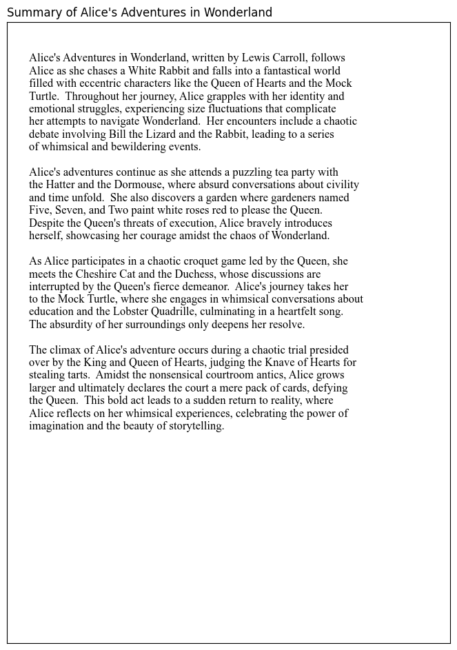

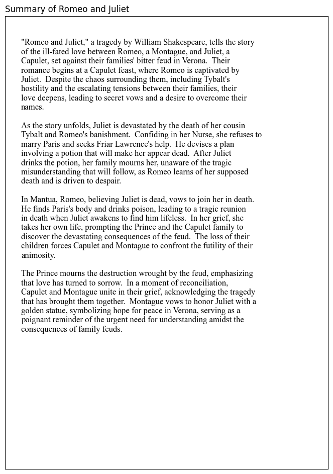

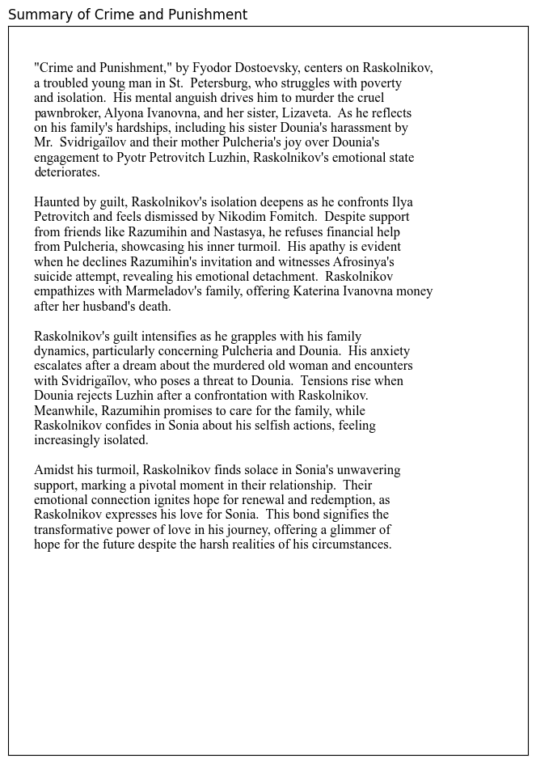

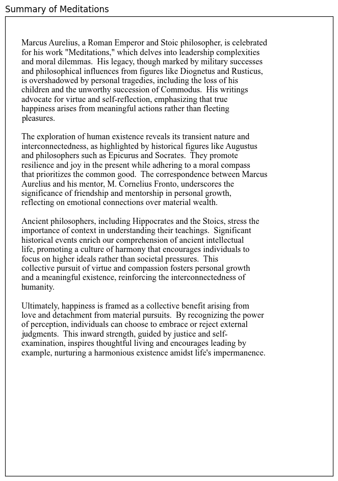

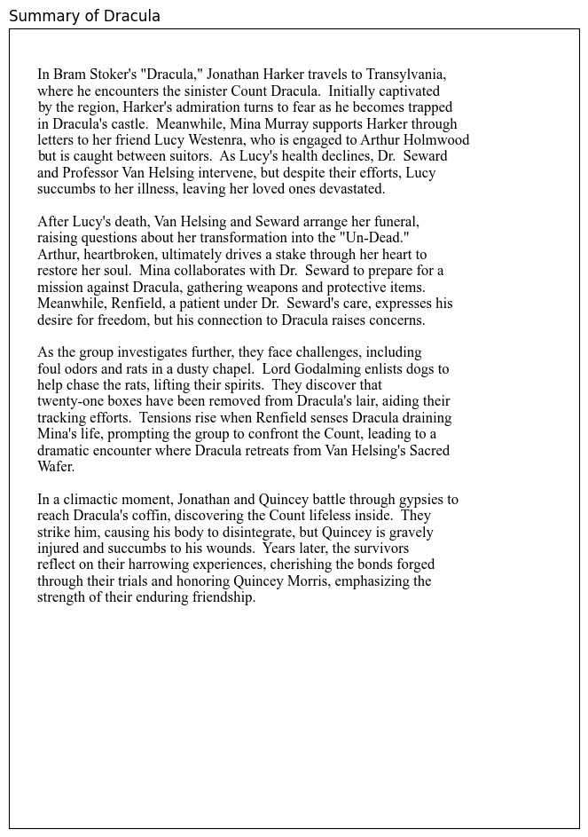

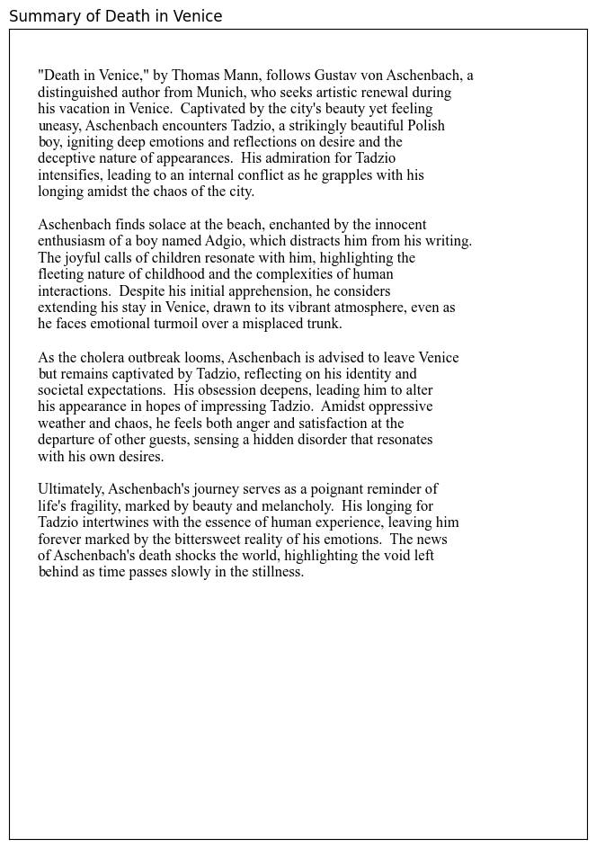

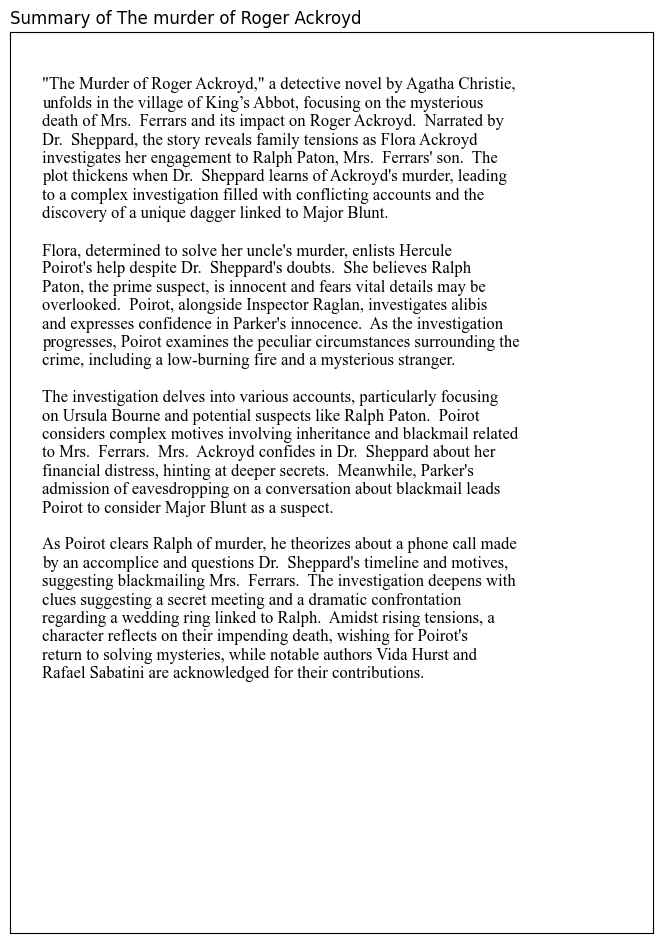

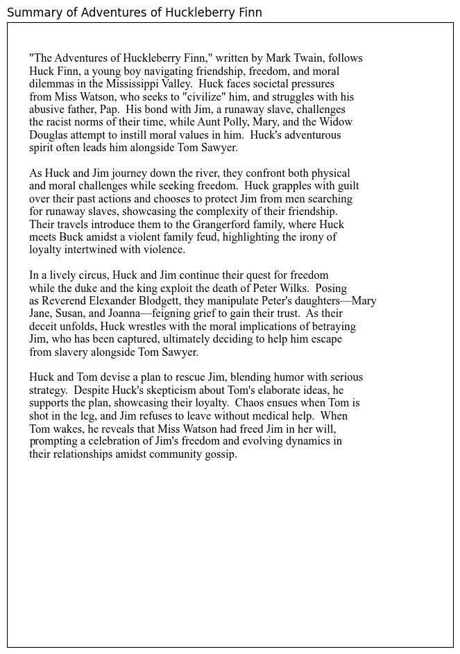

```python
%matplotlib inline
text_plotter = TextPlotterManager(
    documents=summarized_text, titles=list(book_names.values())
)
text_plotter.plot_text()
```